# Stats 6500 Exploratory Data Analysis- Autonomous Vehicle Accidents

Charmchi Toosi, Shahrzad; Chu, Yue; Heider, Jennifer E.; Lin, Yue; Smillie, Katie;

# Background

- Development of autopilot features of cars.
- Debates around the technology and concerns on safety of autopilot technology.

# Key research question

In this study, we aim to evaluate the safety of autonomous vehicles using a dataset of collision reports.

# Data

| Variable | Label |
| --- | --- |
| Date | Date of accident |
| Address | Address of accident |
| Car.type | Type of car |
| Company | Make of car |
| Autonomous | Whether autonomous vehicle is engaged(1=yes,0=no) |
| Time | Time of accident |
| Weather | Weather condition when the accident occurred |
| Road.condition | Road condition |
| Lighting | Lighting condition |
| Unusual.conditions | Other unusual conditions |
| Stop.moving1 | Whether the vehicle stopped or was moving |
| Stop.moving2 | Whether the other vehicle stopped or was moving |
| Other.vehicle | [All N/A] |
| Damage | How severe the damage was |
| Significance | Effect on human |
| Injury | [All N/A] |
| Explanation | Type of collision |
| Error | AV or non-AV fault |

# Data Preparation

The variables Injury and Other Vehicle will be excluded because they are completely missing. Weather, lighting, road conditions, and unusual conditions all have 67 missing observations. The original PDF accident reports will be used later to fill in the missing values. Variables with spaces in the names will be renamed for ease of use in R.

```
##                                 Date                              Address
##                                    0                                    0
##                              Company                             Car Type
##                                    0                                    0
## Autonomous engaged (1 = yes, 0 = no)                                 Time
##                                    0                                   10
##                              Weather                      Road conditions
##                                   67                                   67
##                             Lighting                   Unusual Conditions
##                                   67                                   67
##                       Stopped/Moving                        Other Vehicle
##                                    0                                  250
##               Stopped/moving (Car 2)                               Damage
##                                    0                                    0
##                         Significance                               Injury
##                                   50                                  250
##                           Expanation                                error
##                                    0                                  100
```

```
## tibble [250 x 16] (S3: tbl_df/tbl/data.frame)
##  $ Date                                : chr [1:250] "5/13/18" "6/26/19" "10/17/19" "3/8/19" ...
##  $ Address                             : chr [1:250] "Franklin St and Vallejo St, San Francisco, San Francisco, CA, 94123" "10th Ave and California St, San Francisco, San Francisco, CA, 94118" "Hyde St and Sutter St, San Francisco, San Francisco, CA, 94109" "16th St and Guerrero St, San Francisco…
##  $ Company                             : chr [1:250] "Cruise" "Cruise" "Cruise" "Cruise" ...
##  $ Car Type                            : chr [1:250] "Chevrolet Bolt 2017" "Chevrolet Bolt 2020" "Chevrolet Bolt 2020" "Chevrolet Bolt 2019" ...
##  $ Autonomous engaged (1 = yes, 0 = no): num [1:250] 1 1 1 1 1 1 1 1 1 1 ...
##  $ Time                                : 'hms' num [1:250] 00:15:00 00:36:00 01:05:00 01:29:00 ...
##   ..- attr(*, "units")= chr "secs"
##  $ Weather                             : chr [1:250] "Clear" "Clear" "Fog" "Clear" ...
##  $ Road conditions                     : chr [1:250] "Dry" "Dry" "Wet" "Dry" ...
##  $ Lighting                            : chr [1:250] "Dark-Street lights" "Dark-Street lights" "Dark-Street lights" "Dark-Street lights" ...
##  $ Unusual Conditions                  : chr [1:250] "No" "No" "No" "No" ...
##  $ Stopped/Moving                      : chr [1:250] "stopped" "moving" "stopped" "moving" ...
##  $ Stopped/moving (Car 2)              : chr [1:250] "moving" "moving" "moving" "moving" ...
##  $ Damage                              : chr [1:250] "moderate" "minor" "minor" "minor" ...
##  $ Significance                        : chr [1:250] "human made aggressive move clipped av" "human unable to react/anticipate av" "human made aggressive move clipped av" "human made aggressive move clipped av" ...
##  $ Expanation                          : chr [1:250] "sideswipe" "rear-end" "rear-end" "rear-end" ...
##  $ error                               : chr [1:250] "non av" "non av" "non av" "non av" ...
```

The column car_type includes information on vehicle year, make, and model. This was split into 3 separate columns for analysis. Misspelling and case differences in Lighting, stopped_av, were also corrected.

| date | address | company | car_type | autonomous_engaged | time | weather | road_cond | lighting | unusual_cond | stopped_av | stopped_nonav | damage | explanation | damage_type | error | car_year | car_make | car_model |
| --- | --- | --- | --- | --- | --- | --- | --- | --- | --- | --- | --- | --- | --- | --- | --- | --- | --- | --- |
| 5/13/18 | Franklin St and Vallejo St, San Francisco, San Francisco, CA, 94123 | Cruise | Chevrolet Bolt 2017 | 1 | 00:15:00 | Clear | Dry | DARK-STREET LIGHTS | No | stopped | moving | moderate | human made aggressive move clipped av | sideswipe | non av | 2017 | Chevrolet | Bolt |
| 6/26/19 | 10th Ave and California St, San Francisco, San Francisco, CA, 94118 | Cruise | Chevrolet Bolt 2020 | 1 | 00:36:00 | Clear | Dry | DARK-STREET LIGHTS | No | moving | moving | minor | human unable to react/anticipate av | rear-end | non av | 2020 | Chevrolet | Bolt |
| 10/17/19 | Hyde St and Sutter St, San Francisco, San Francisco, CA, 94109 | Cruise | Chevrolet Bolt 2020 | 1 | 01:05:00 | Fog | Wet | DARK-STREET LIGHTS | No | stopped | moving | minor | human made aggressive move clipped av | rear-end | non av | 2020 | Chevrolet | Bolt |
| 3/8/19 | 16th St and Guerrero St, San Francisco, San Francisco, CA, 94103 | Cruise | Chevrolet Bolt 2019 | 1 | 01:29:00 | Clear | Dry | DARK-STREET LIGHTS | No | moving | moving | minor | human made aggressive move clipped av | rear-end | non av | 2019 | Chevrolet | Bolt |
| 3/24/18 | Sutter St and Grant St, San Francisco, San Francisco, CA, 94108 | Cruise | Chevrolet Bolt 2017 | 1 | 01:54:00 | NA | NA | NA | NA | moving | moving | minor | human unable to react/anticipate av | rear-end | non av | 2017 | Chevrolet | Bolt |
| 10/7/17 | 14th St and Valencia St, San Francisco, San Francisco, CA, 94103 | Cruise | Chevrolet Bolt 2017 | 1 | 02:35:00 | NA | NA | NA | NA | moving | moving | none | human unable to react/anticipate av | rear-end | non av | 2017 | Chevrolet | Bolt |

|  | car_model | ct |
| --- | --- | --- |
| 1 | Bolt | 126 |
| 2 | Fusion | 6 |
| 3 | Highlander | 20 |
| 4 | Leaf | 3 |
| 5 | Pacifica | 55 |
| 6 | Prius | 1 |
| 7 | NA | 39 |

## Make some tables

For analysis of autonomous vehicle safety, the fields indicating damage level and type, whether autononomous driving was engaged, autonomous vehicle errors, and whether the autonomous vehicle was determined to be at fault appear to be interesting. Looking at the count tables, most of the damage was minor, with rear-end being the most common followed by sideswipe. Autonomous was engaged for most accidents, but AV was flagged as not as fault for most accidents.

Predictor variable sparsity will be a challenge in this dataset. Most of the accident records are from clear days, during daylight, with dry road conditions. Bolts make up the large proportion of car models, followed by Pacifica.

```
##              NA
## Damage        broadside head-on other parking rear-end sideswipe
##   major               0       0     0       0        1         1
##   minor              10       1    13       8      108        32
##   moderate            4       1     2       1       20        14
##   none                5       2     1       1       21         2
##   significant         1       0     0       0        1         0
```

```
##                   NA
## Autonomous Engaged  av non av unclear
##                  0   0      1       0
##                  1   4    144       1
```

```
## Company
## AI Motive     Apple    Aurora    Cruise  Drive AI   Jingchi      Lyft    Nissan
##         1         3         4       128         1         1         6         1
##   Pony AI    Toyota      UATC     Waymo      Zoox
##         2         1         3        79        20
```

```
## Car Type
##    Chevrolet Bolt 2016    Chevrolet Bolt 2017    Chevrolet Bolt 2019
##                      3                     46                     32
##    Chevrolet Bolt 2020 Chrysler Pacifica 2017       Ford Fusion 2017
##                     45                     55                      1
##       Ford Fusion 2018            Google 2015                  Lexus
##                      5                      9                      3
##            Lexus  2011             Lexus 2012             Lexus 2013
##                      1                      8                      1
##             Lexus 2015             Lexus 2016             Lexus 2017
##                      2                      2                      2
##           Lincoln 2017           Lincoln 2018            Nissan 2016
##                      5                      2                      1
##       Nissan Leaf 2010       Nissan Leaf 2012 Toyota Highlander 2016
##                      1                      2                     19
## Toyota Highlander 2017      Toyota Prius 2010             volvo 2017
##                      1                      1                      1
##             Volvo 2017
##                      2
```

```
## Car Make
## Chevrolet  Chrysler      Ford    Google     Lexus   Lincoln    Nissan    Toyota
##       126        55         6         9        19         7         4        21
##     Volvo
##         3
```

```
## Car Model
##       Bolt     Fusion Highlander       Leaf   Pacifica      Prius
##        126          6         20          3         55          1
```

```
## Car Year
## 2010 2011 2012 2013 2015 2016 2017 2018 2019 2020
##    2    1   10    1   11   25  113    7   32   45
```

```
## weather
##   Clear  Cloudy     Fog Raining
##     160      17       3       3
```

```
## Road Conditions
## Dry Wet
## 174   9
```

```
## Lighting
## DARK-STREET LIGHTS               DAWN           DAYLIGHT               DUSK
##                 38                  3                137                  5
```

```
## Lighting
## Construction Zone                No     Reduced width
##                 2               179                 2
```

```
##           NA
## Stopped AV moving N/A stopped
##    moving     123   9      13
##    stopped    101   3       1
```

```
## Day
##    Sunday    Monday   Tuesday Wednesday  Thursday    Friday  Saturday
##        24        36        35        43        45        39        28
```

```
## Month
##   January  February     March     April       May      June      July    August
##        24        15        15        11        23        22        23        24
## September   October  November  December
##        25        32        24        12
```

```
## Year
## 2015 2016 2017 2018 2019 2020
##    8   16   29   76  104   17
```

## Barplots of Factor Variables

Most of the variables in this dataset are categorical. Since some of the categories are low count, it might be useful in modeling to consolidate low frequency categories as “Other”. For example, car make has high record counts for Chevrolet, Chrsysler, Toyota, and Lexus, but Nissan, Lincoln, Volvo, Google, and Ford occur infrequently.

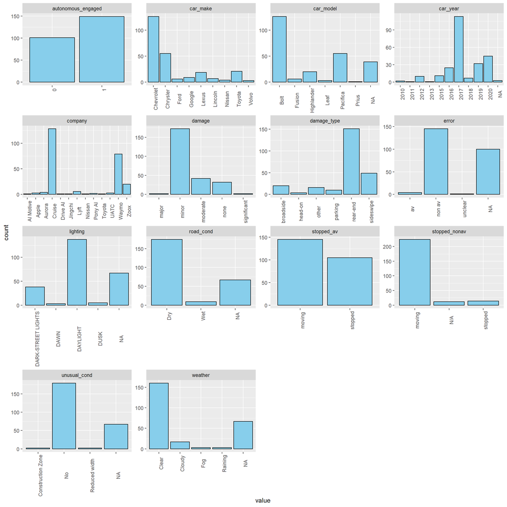

Most of the data in this dataset is from 2019. Thursday was the most common day for accidents, and October had the highest count of accidents.

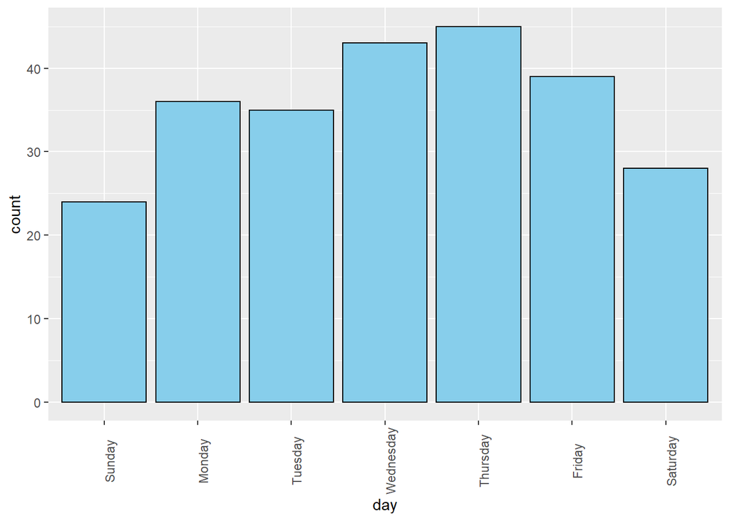

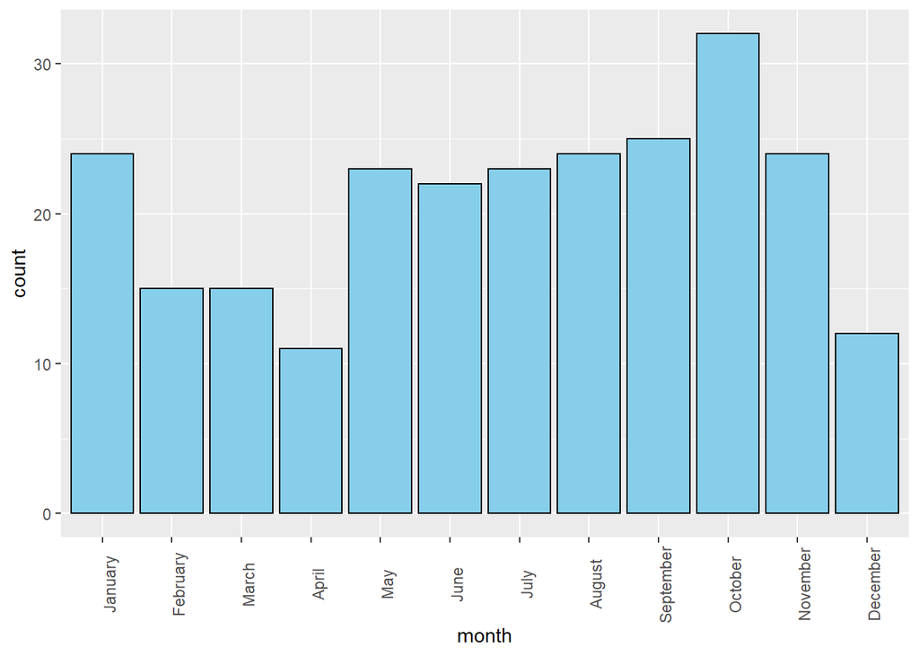

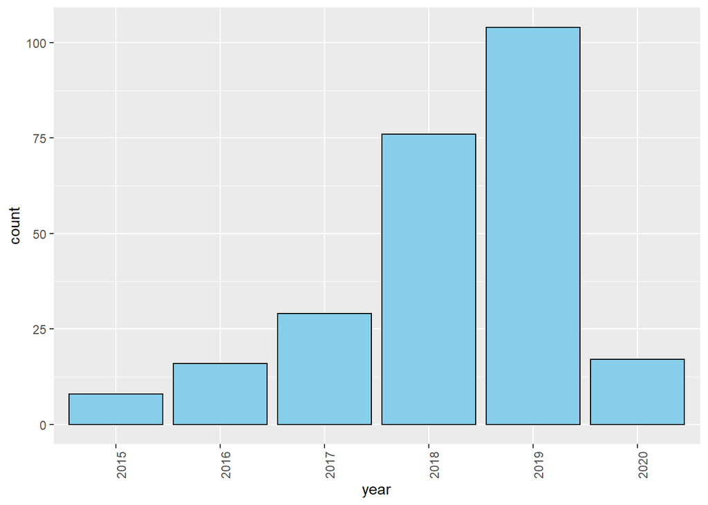

## Plots of Variable Relationships

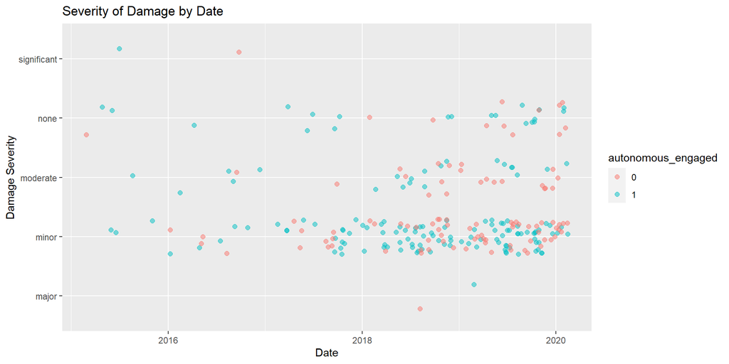

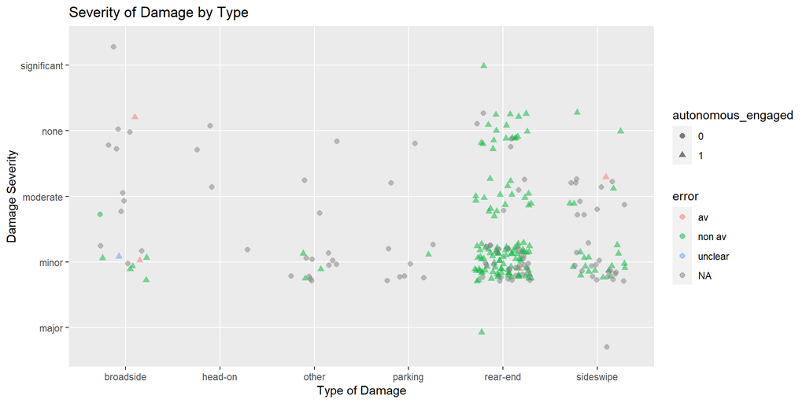

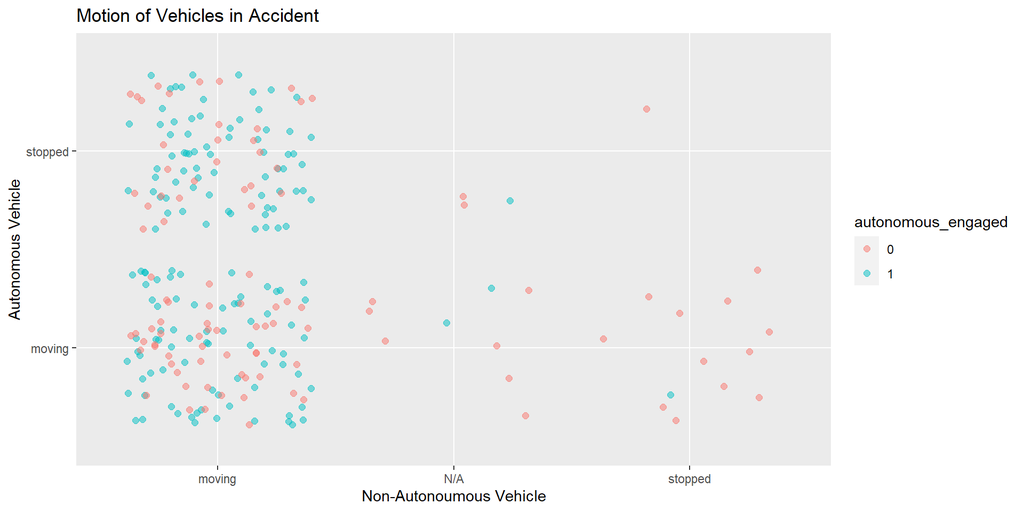

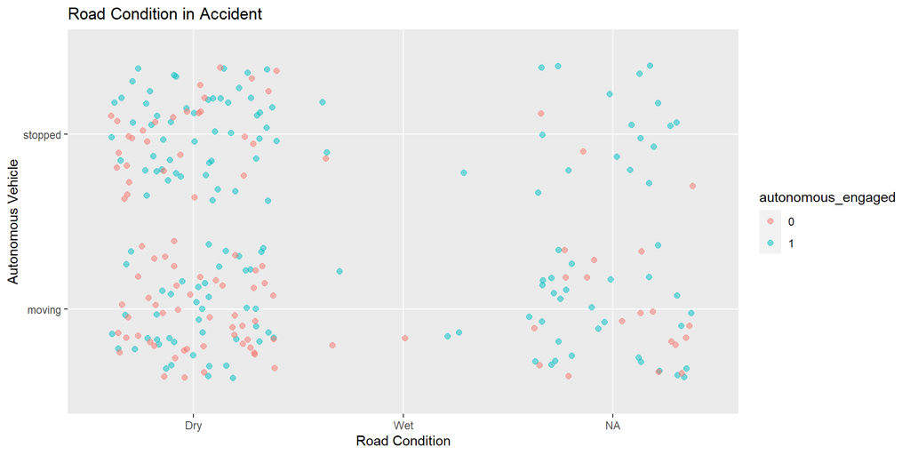

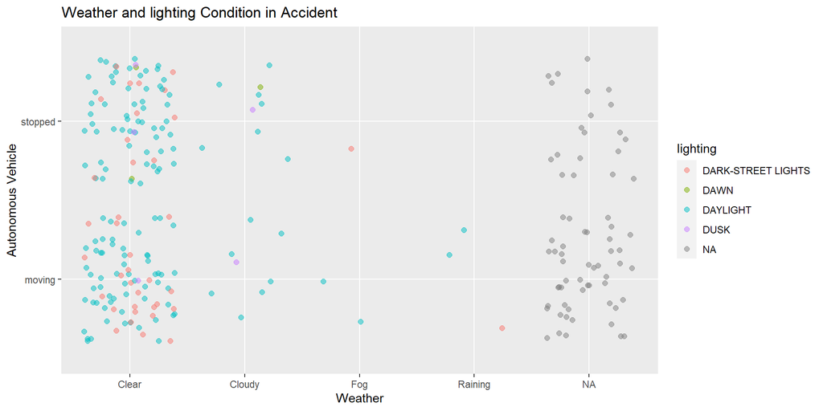

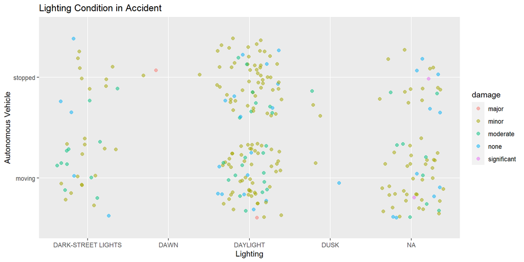

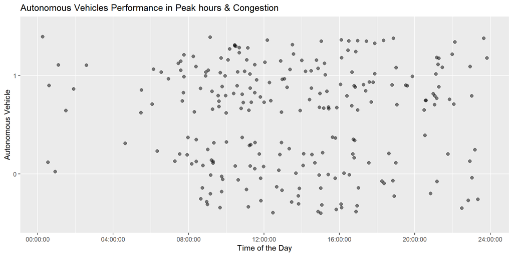

## Examine relationships between damage and other variables

The variables weather, autonomous engaged, and conditions look like they could be useful to predict accident severity. As previously discussed, he other variables may prove to be more useful once they are condensed into fewer categories.

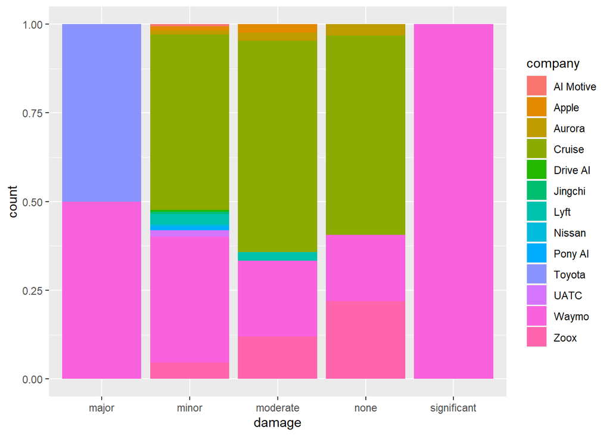

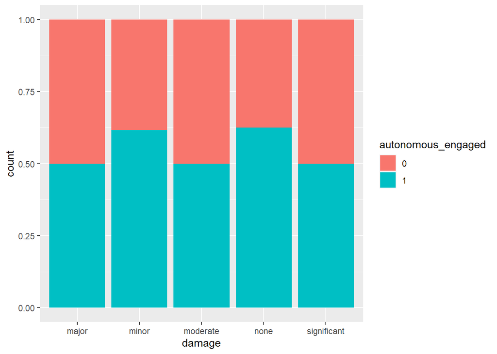

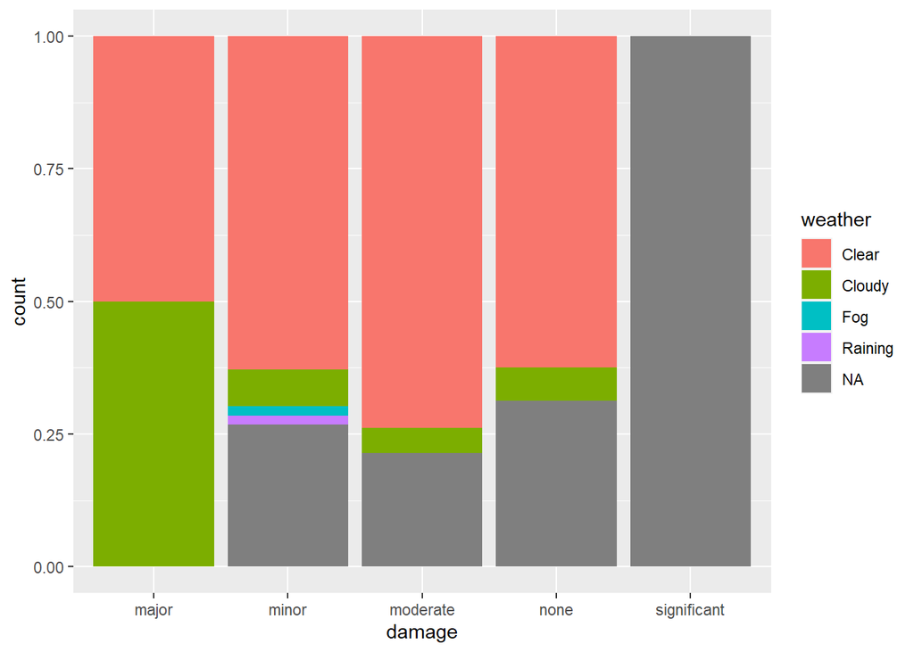

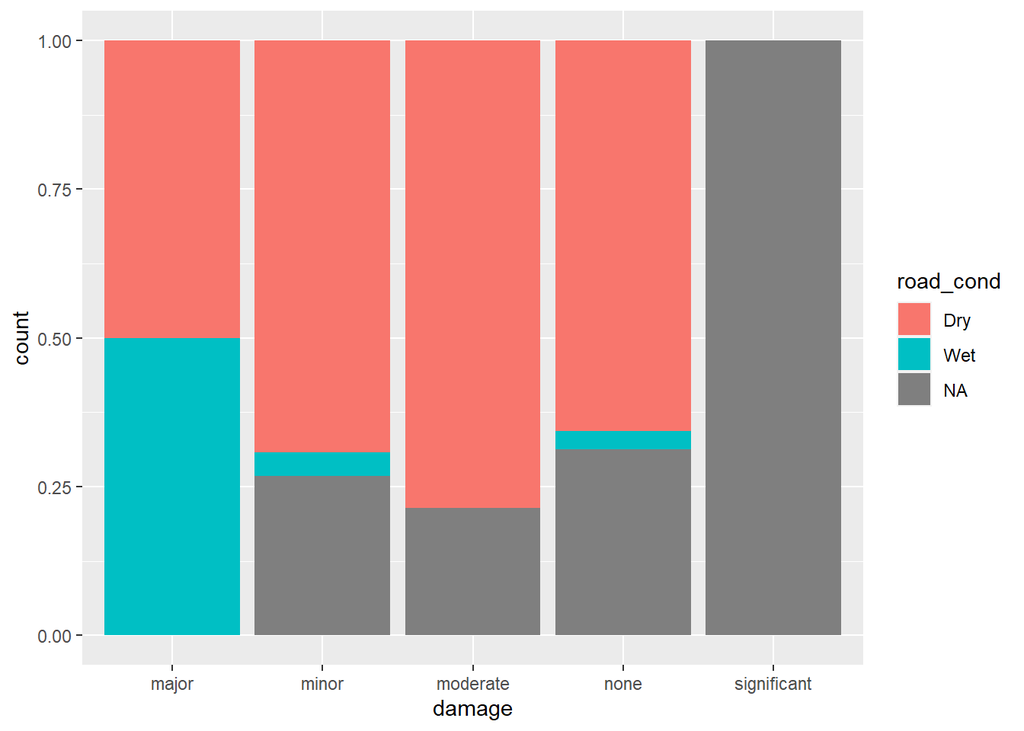

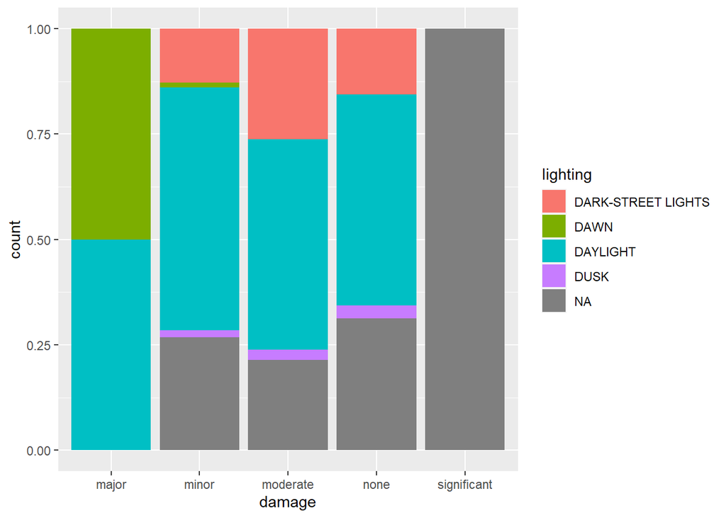

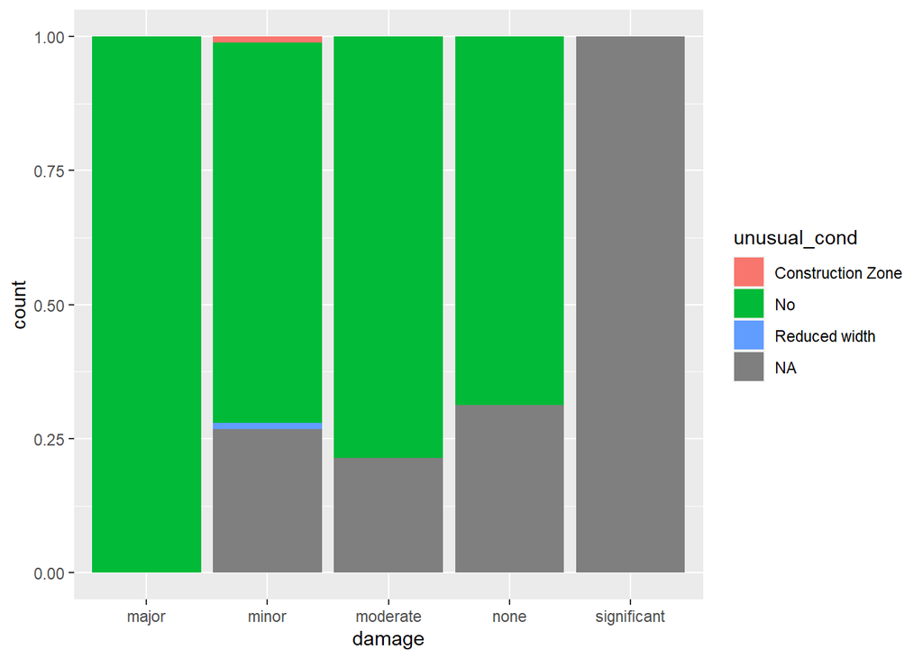

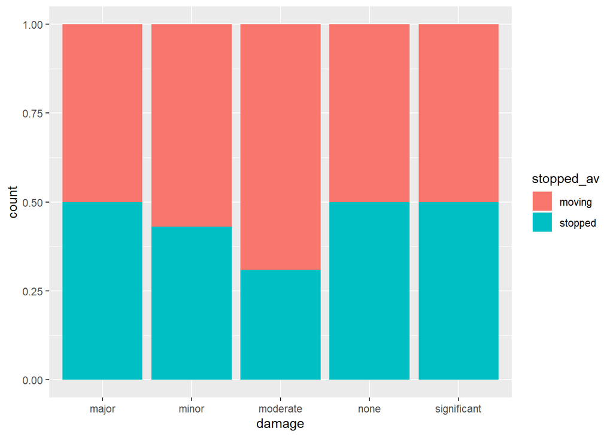

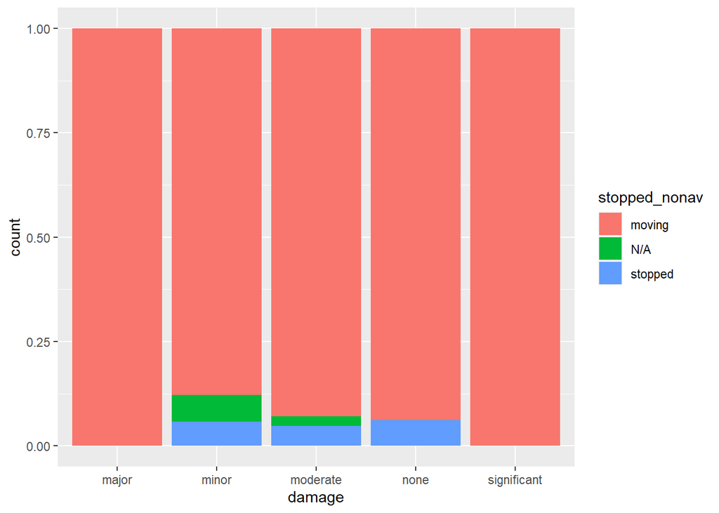

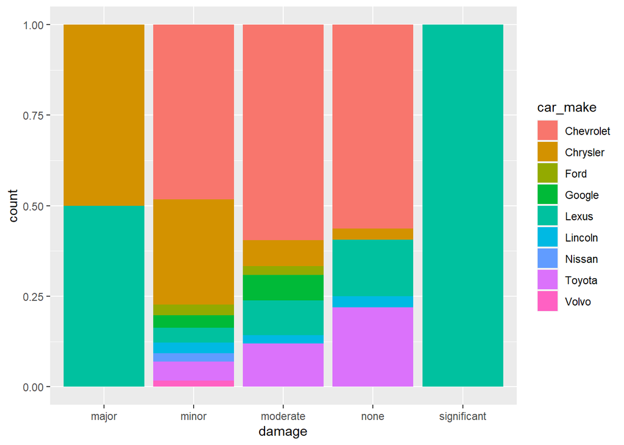

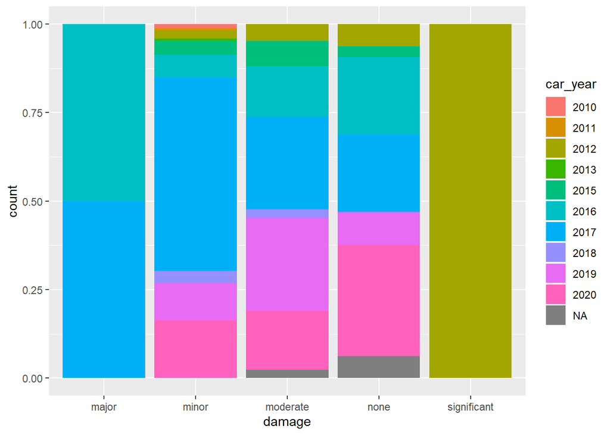

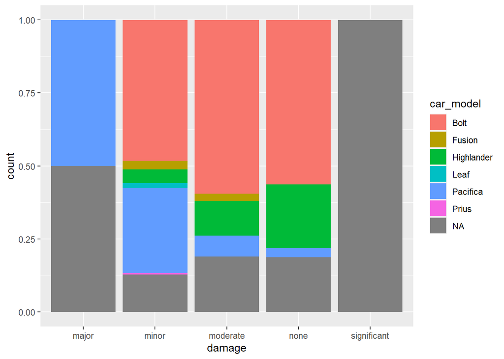

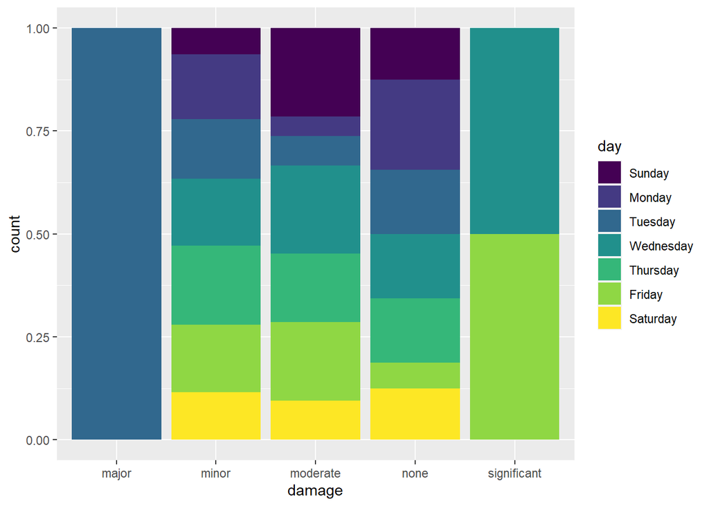

[1 more figures not shown]

## Examine relationships between error and other predictors

Weather and lighting look like they could be useful for predicting autonomous vehicle errors.

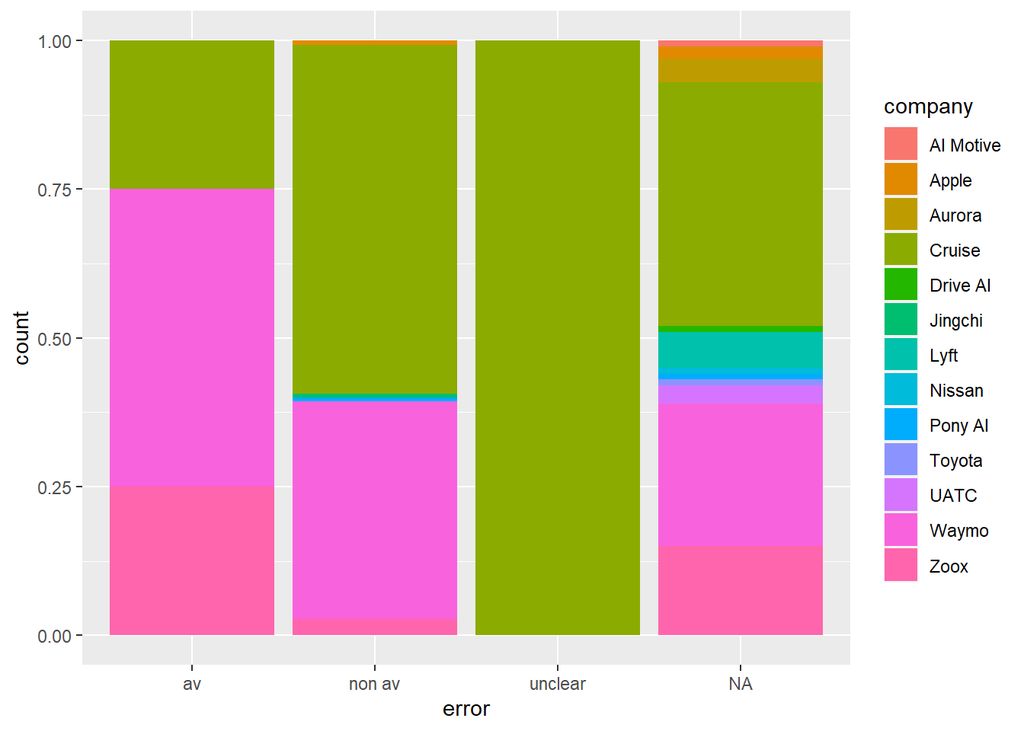

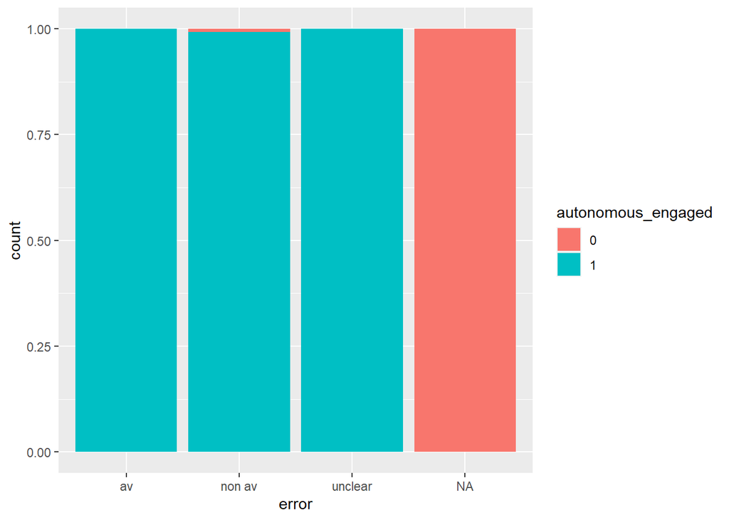

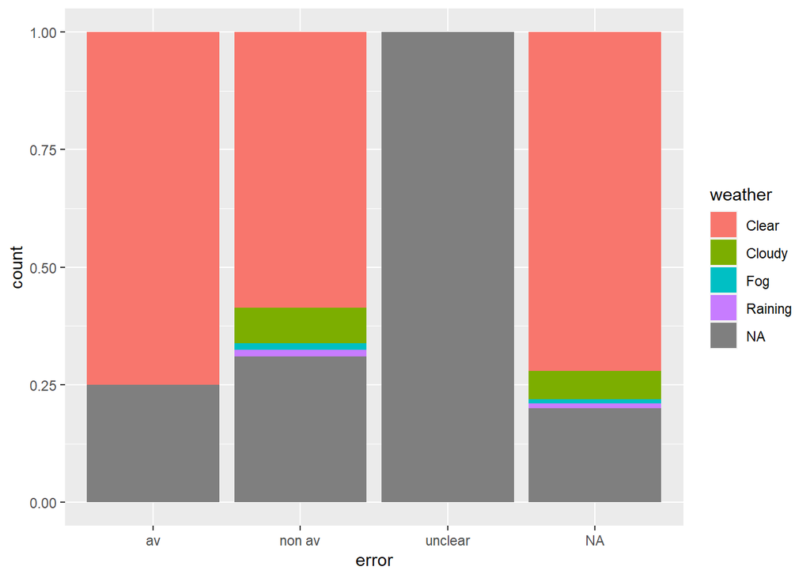

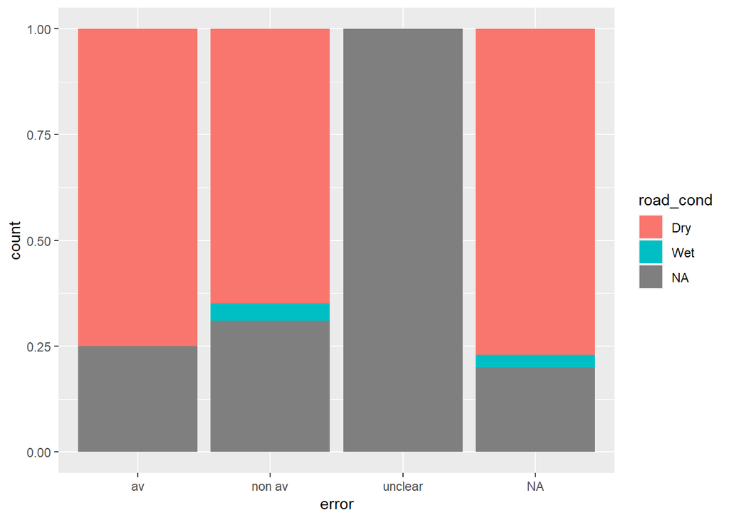

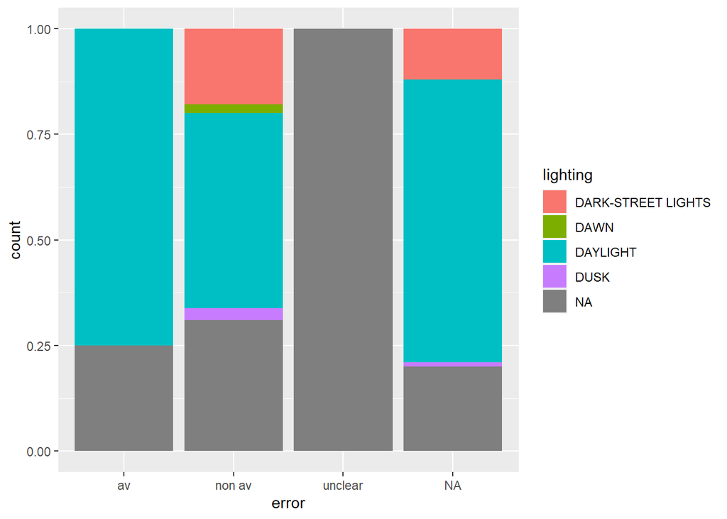

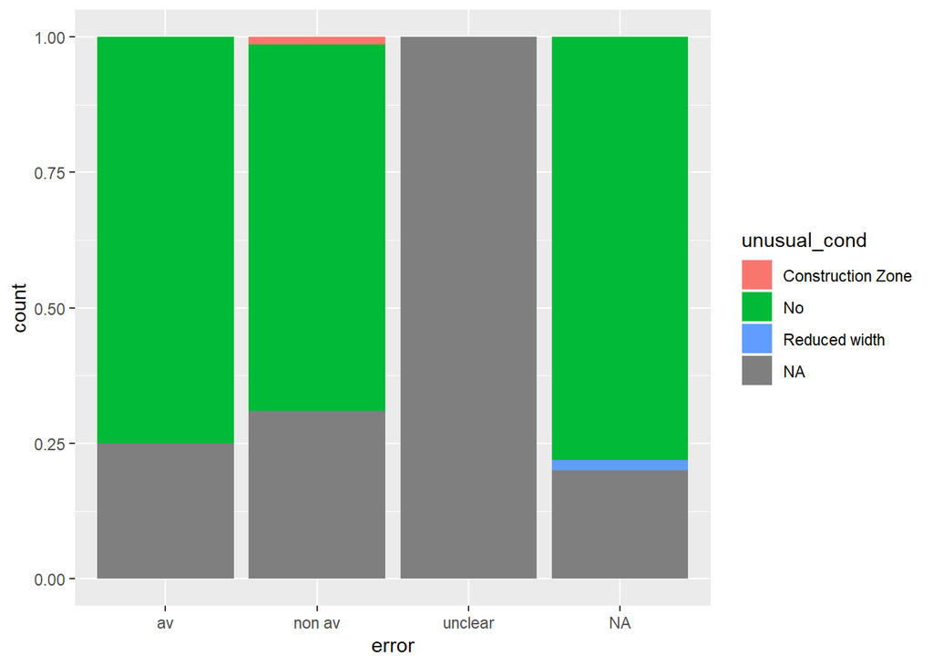

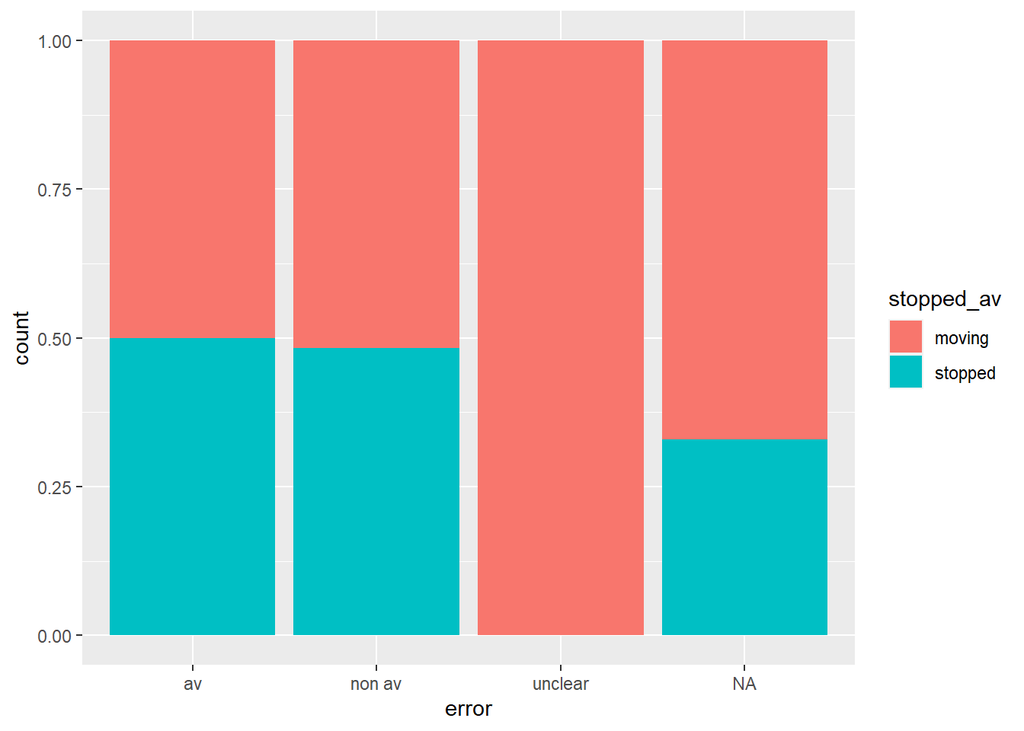

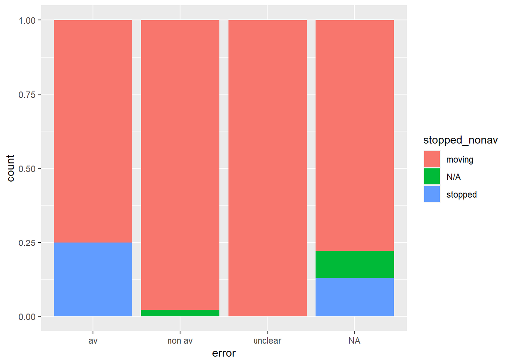

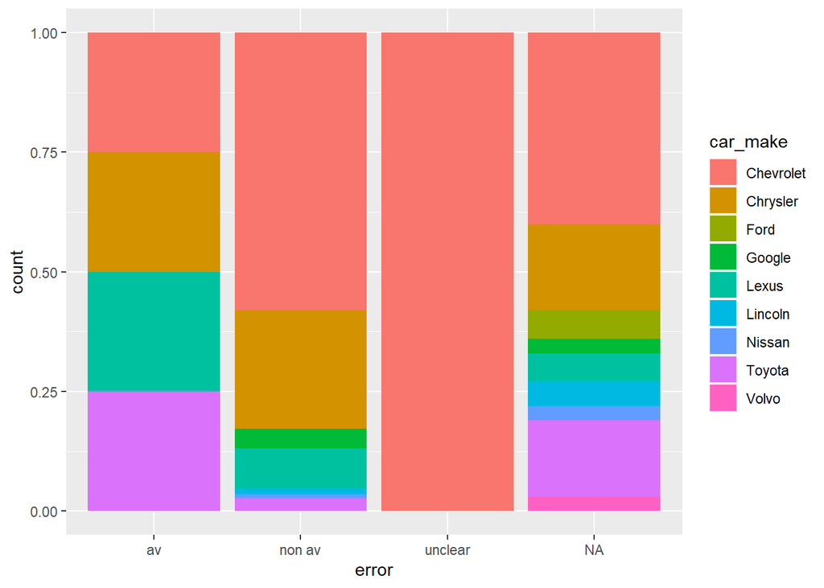

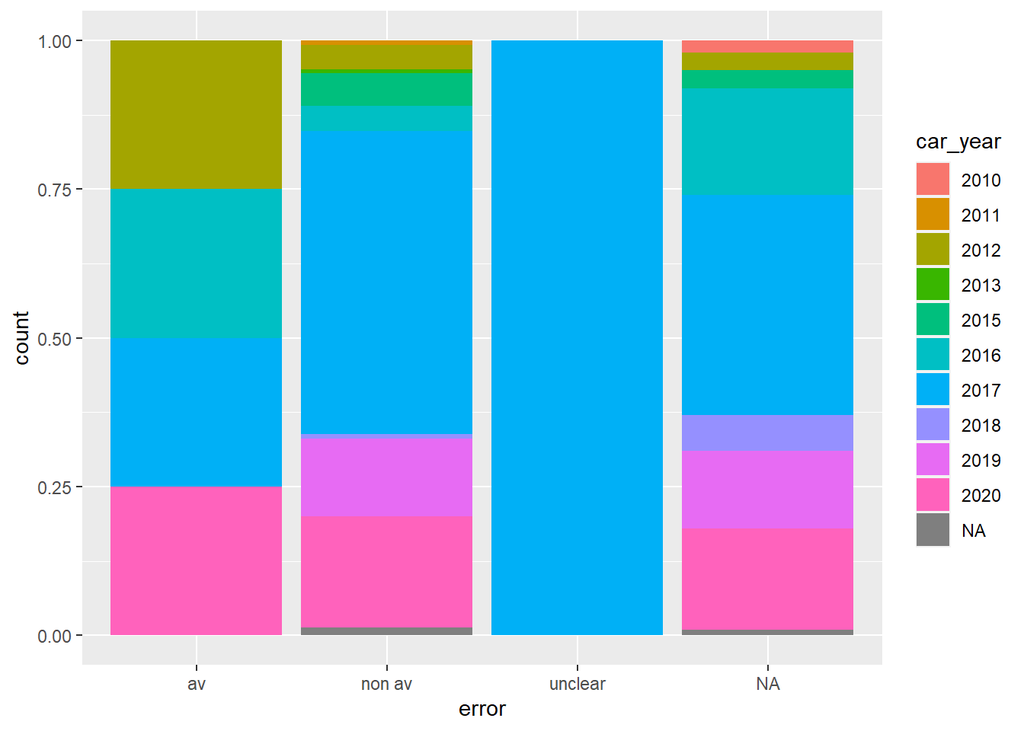

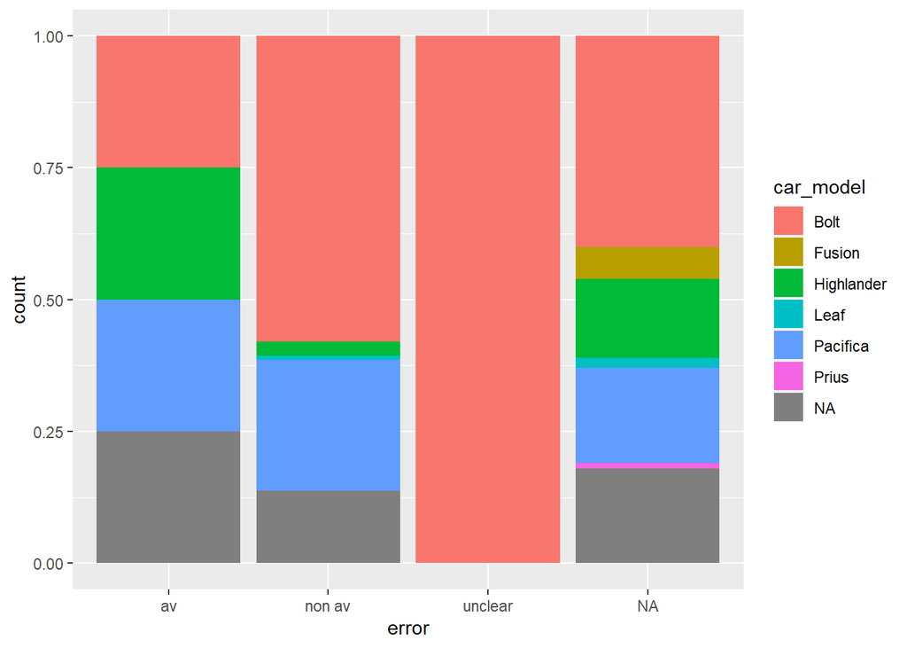

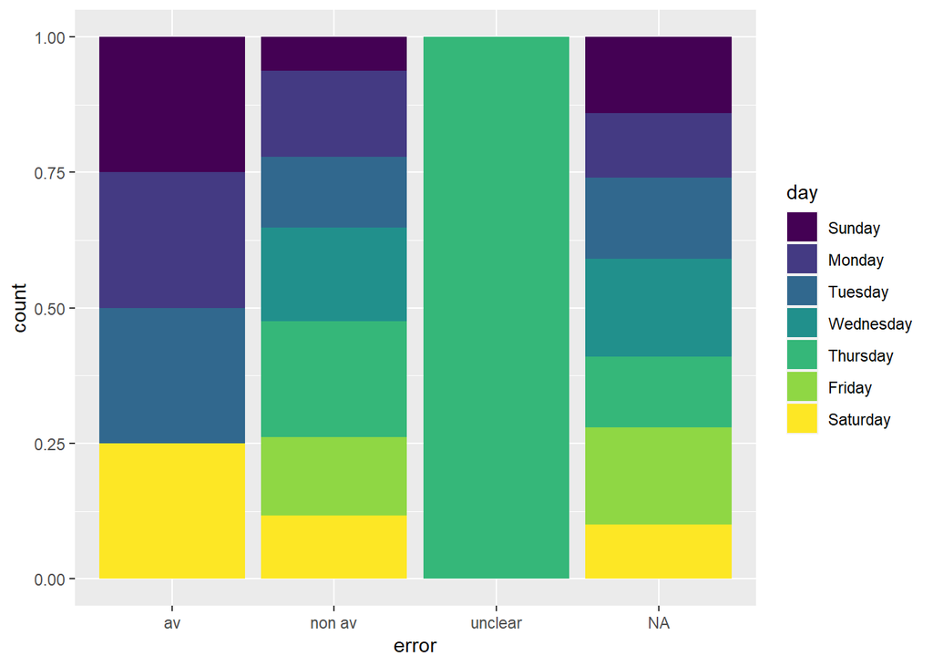

[1 more figures not shown]